# Data_Preparation_and_Customer_Analytics

#### Sample t-Test for Pack Size (unequal sample size and unequal variances)

```python
mask =(transaction_customer.LIFESTAGE == 'YOUNG SINGLES/COUPLES') & (transaction_customer.PREMIUM_CUSTOMER == 'Mainstream')
target_segment = transaction_customer[mask]
other_segment = transaction_customer[~mask]
```

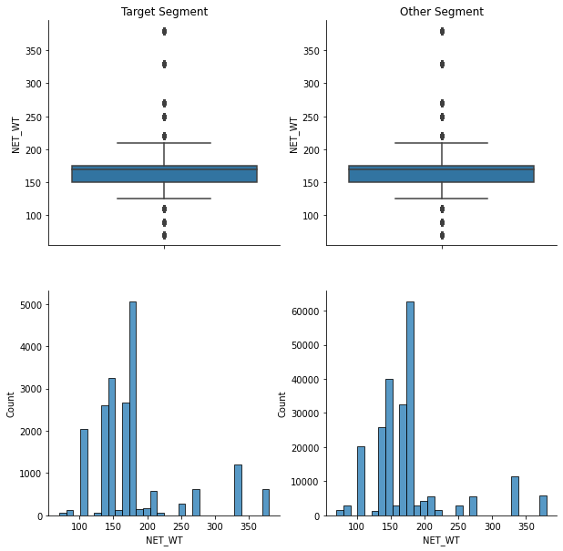

```python
# boxplot and histplot
plt.subplots(2,2, sharey=True, figsize = (10, 10));
plt.subplot(2,2,1);
sns.boxplot(y = target_segment['NET_WT']);
plt.title('Target Segment')
plt.subplot(2,2,2);
sns.boxplot(y = other_segment['NET_WT']);
plt.title('Other Segment')

plt.subplot(2,2,3);
sns.histplot(x = target_segment['NET_WT'], bins = 30);

plt.subplot(2,2,4);
sns.histplot(x = other_segment['NET_WT'], bins = 30);
sns.despine()
```

```python
# calculate the Standard Deviation
# set alpha
alpha = 0.05
# calculate the variance to get standard deviation
# For unbiased max likelyhood estimate we have to divide the var by N-1
# and therefore the parameter ddof = 1
var_a = target_segment['NET_WT'].var(ddof=1)
var_b = other_segment['NET_WT'].var(ddof = 1)
# calculate the means
m_a = target_segment['NET_WT'].mean()
m_b = other_segment['NET_WT'].mean()
# calculate the sample size
n_a = len(target_segment)
n_b = len(other_segment)
# t-statistic
t = (m_a - m_b)/np.sqrt(var_a/n_a + var_b/n_b)
# compare with critical values
# degree of freedom
df = n_a + n_b - 2
# p_value after comparison with the t
p = 1 - stats.t.cdf(t, df = df)

print('p-value: ', p/2)
print('Is p-value smaller than alpha of 0.05?', p/2 < alpha)
```

```
p-value:  1.5992929203179074e-11
Is p-value smaller than alpha of 0.05? True
```

### Insights

- Top 3 total sales contributed by
  - Older Families - Budget $(\$158,380)$
  - Young Singles/Couples - Mainstream $(\$148,337)$
  - Retirees - Mainstream $(\$146,328)$
- Top 3 sales per capita contributed by
  - Midage Singles/Couples - Mainstream $(\$7.613)$
  - Young Singles/Couples - Mainstream $(\$7.528)$
  - Retirees - Premium $(\$7.435)$
- Top 3 number of pack bought by
  - Older Families - Mainstream 1.949 pack
  - Older Families - Premium 1.946 pack
  - Older Families - Budget 1.945 pack
- Top 3 unit price bought by
  - Young Singles/Couples - Mainstream $(\$4.054)$
  - Midage Singles/Couples - Mainstream $(\$3.982)$
  - Retirees - Budget $(\$3.912)$

Since Young Single/Couples are the willing to pay more unit price aroung 4 dollars. We look at the popluar brands amoung this customer segment.

- Top 3 popular brands among the segment
  - Kettle
  - Doritos
  - Pringles

Compared two segments, The unit price for mainstream, young and mid-age singles and coules are significant higher than that of budget or premium, young and midage singkes and couples

Compared two segments, It is significant that young singles/couples - mainstream is buying larger pack size than other segment.